# Test Your Knowledge of PCA, SVD and Censoring

Term 5, 2024

# Question 1

## a)

The data has a total of 9 documents and 460 terms. From the figure we see that documents 7 and 8 seem closest to each other in the low dimensional representation from the figure.

```r
lsiMatrix <- read.table("lsiMatrix.txt")
str(lsiMatrix)
```

```
## 'data.frame':    9 obs. of  460 variables:
##  $ V1  : int  2 0 4 0 0 0 0 0 0
##  $ V2  : int  0 0 2 0 0 0 0 0 0
##  $ V3  : int  0 0 0 3 0 0 0 0 0
##  $ V4  : int  0 0 0 0 0 0 2 0 0
##  $ V5  : int  0 0 0 0 0 0 0 2 0
##  $ V6  : int  0 0 2 0 0 0 0 0 0
##  $ V7  : int  0 0 2 0 0 0 0 0 0
##  $ V8  : int  2 0 0 0 0 0 0 0 0
##  $ V9  : int  0 27 13 23 19 48 56 35 22
##  $ V10 : int  4 2 3 7 4 0 5 8 4
##  $ V11 : int  4 2 3 6 4 0 5 8 4
##  $ V12 : int  2 0 0 0 0 0 0 0 2
##  $ V13 : int  34 30 27 83 26 74 39 49 38
##  $ V14 : int  6 0 12 2 20 5 15 16 7
```

[output cut: 86 more lines]

```r
X <- as.matrix(t(lsiMatrix))
dim(X)
```

```
## [1] 460   9
```

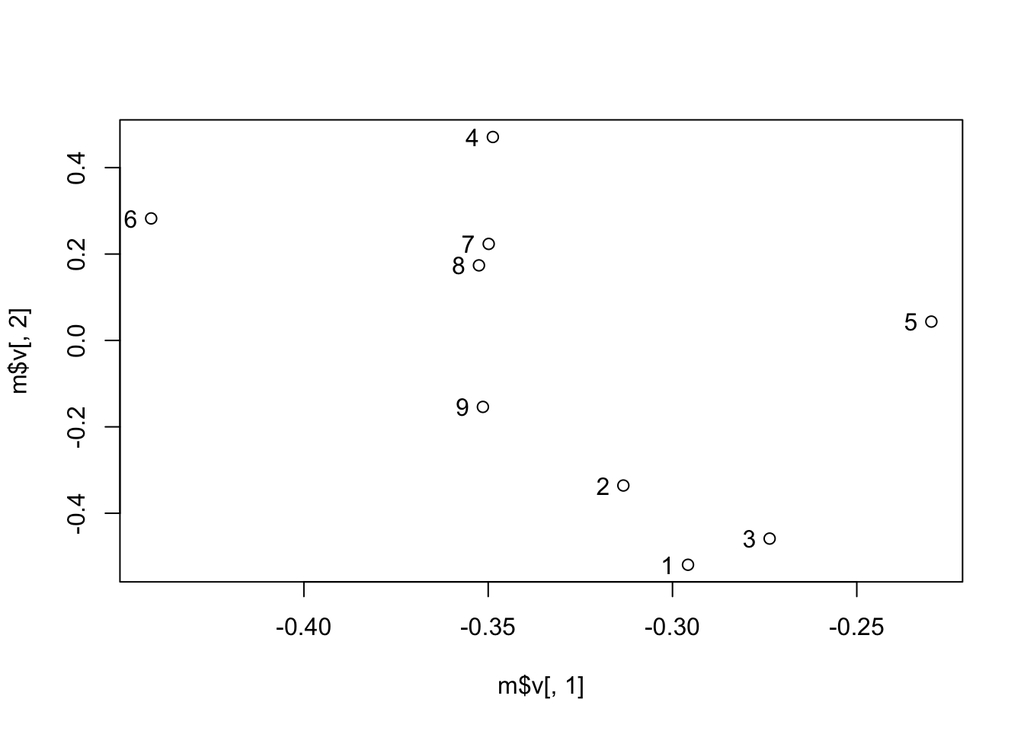

```r
m <- svd(X)
mreduced <- m$u[,1:2]%*%diag(m$d[1:2])%*%t(m$v[,1:2])
plot(m$v[,1],m$v[,2])
text(m$v[,1],m$v[,2],c(1:9),adj=2)
```

## b)

To find a low dimensional representation of 1, where $X = USV^{\top}$ is the SVD, we need to solve $US \hat{q} = q$ which gives $\hat{q} = S^{-1} U^{\top}q$. The top 3 matches are documents 1, 3 and 2.

```r
q <- matrix(0,nrow=460,ncol=1)
q[23] <- 1
hatq <- solve(diag(m$d[1:2]))%*%t(m$u[,1:2])%*%q
str(hatq)
```

```
##  num [1:2, 1] -3.45e-05 -6.40e-04
```

```r
cosine <- matrix(0,9,1)
for(i in 1:9){
  cosine[i] <- sum(hatq*m$v[i,1:2])/sqrt(sum(hatq^2)*sum(m$v[i,1:2]^2))
}
order(cosine,decreasing=TRUE)
```

```
## [1] 1 3 2 9 5 8 7 6 4
```

# Question 2

This question involves the use of principal component analysis on the well-known `iris` dataset. The dataset is available in R.

## a)

There are 150 observations. There are four different attributes (of type numeric): *Sepal length, Sepal width, Petal length* and *Petal width*. The fifth field gives the *Species* which are of three types: *setosa, versicolor, virginica*.

```r
dim(iris)
```

```
## [1] 150   5
```

```r
str(iris)
```

```
## 'data.frame':    150 obs. of  5 variables:
##  $ Sepal.Length: num  5.1 4.9 4.7 4.6 5 5.4 4.6 5 4.4 4.9 ...
##  $ Sepal.Width : num  3.5 3 3.2 3.1 3.6 3.9 3.4 3.4 2.9 3.1 ...
##  $ Petal.Length: num  1.4 1.4 1.3 1.5 1.4 1.7 1.4 1.5 1.4 1.5 ...
##  $ Petal.Width : num  0.2 0.2 0.2 0.2 0.2 0.4 0.3 0.2 0.2 0.1 ...
##  $ Species     : Factor w/ 3 levels "setosa","versicolor",..: 1 1 1 1 1 1 1 1 1 1 ...
```

## b)

```r
 iris_data<-iris[,-5]
 iris_sp<-iris[,5]
```

## c)

*Petal length* and *Petal width* seems highly positively correlated. Next *sepal length* and *petal length* are also positively correlated. *Sepal length* and *petal width* also seems quite positively correlated.

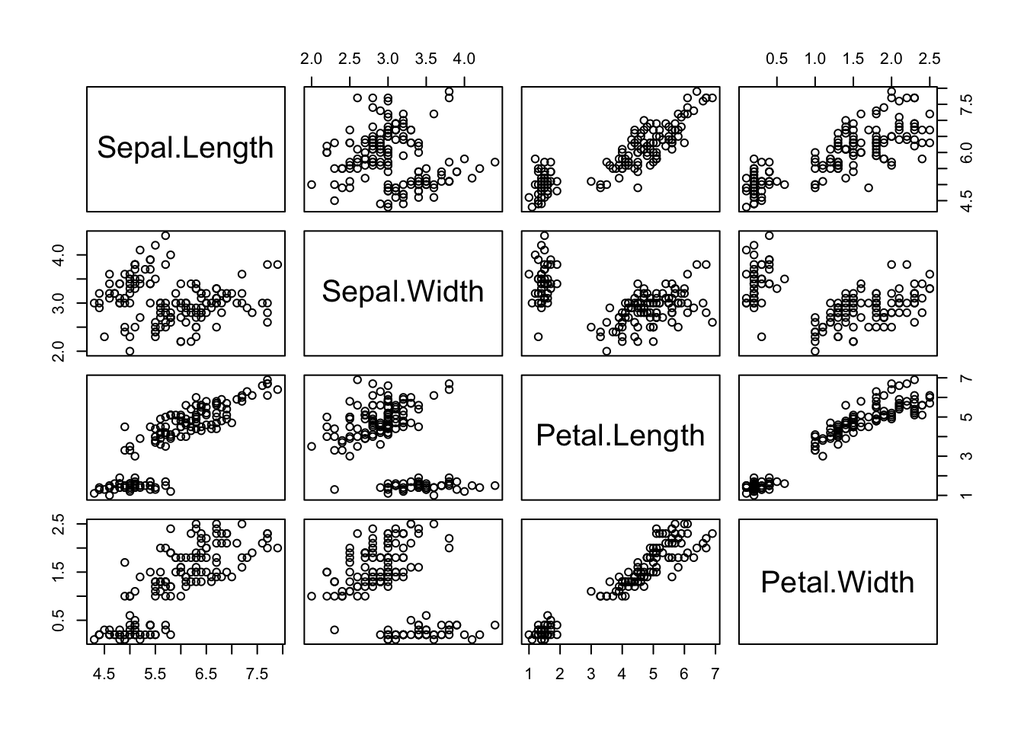

```r
pairs(iris_data)
```

```r
cor(iris_data)
```

```
##              Sepal.Length Sepal.Width Petal.Length Petal.Width
## Sepal.Length    1.0000000  -0.1175698    0.8717538   0.8179411
## Sepal.Width    -0.1175698   1.0000000   -0.4284401  -0.3661259
## Petal.Length    0.8717538  -0.4284401    1.0000000   0.9628654
## Petal.Width     0.8179411  -0.3661259    0.9628654   1.0000000
```

## d) i)

Clearly in this case, the first principal component already explains more than $90\%$ of the variability in the data set (in fact $92.46\%$ of the variability in the dataset).

```r
pr_out<-prcomp(iris_data,scale=F)
summary(pr_out)
```

```
## Importance of components:
##                           PC1     PC2    PC3     PC4
## Standard deviation     2.0563 0.49262 0.2797 0.15439
## Proportion of Variance 0.9246 0.05307 0.0171 0.00521
## Cumulative Proportion  0.9246 0.97769 0.9948 1.00000
```

```r
pr_out$sdev
```

```
## [1] 2.0562689 0.4926162 0.2796596 0.1543862
```

```r
pve<-pr_out$sdev^2/sum(pr_out$sdev^2)
cpve<-cumsum(pve)
pve
```

```
## [1] 0.924618723 0.053066483 0.017102610 0.005212184
```

```r
cpve
```

```
## [1] 0.9246187 0.9776852 0.9947878 1.0000000
```

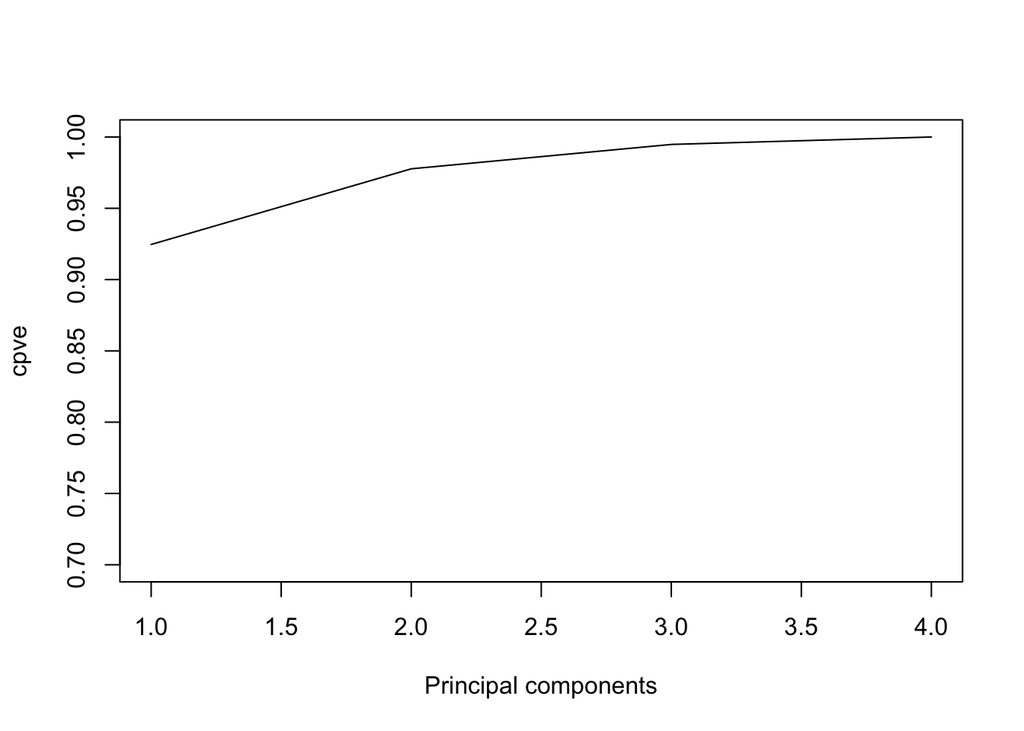

```r
plot(cpve,xlab="Principal components",type="l",ylim=c(0.7,1))
```

In general it is suggested that data be scaled prior to conducting PCA.

## d) ii)

The first principal component already seems to create a separation between *setosa* and the other two categories, although *versicolor* seems to be quite close to *virginica*. Moreover, it appears the same proportions of *Petal length* and *Petal width* are used in both PC1 and PC2 (the only difference is the magnitude). We can also create 95% confidence bounds of ellipses around the groups to see how much they are separated.

```r
library(factoextra)
```

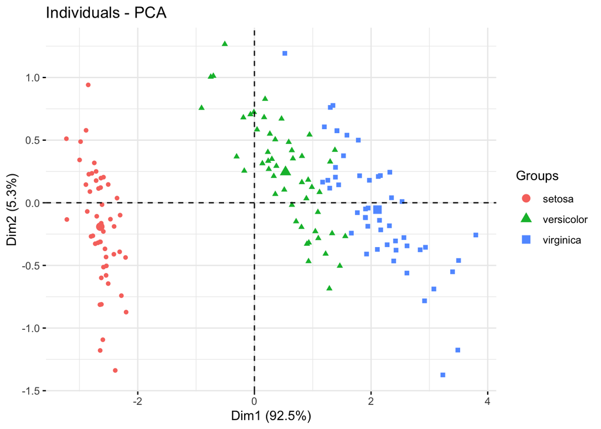

```r
fviz_pca_ind(pr_out, label = "var", habillage=iris_sp)
```

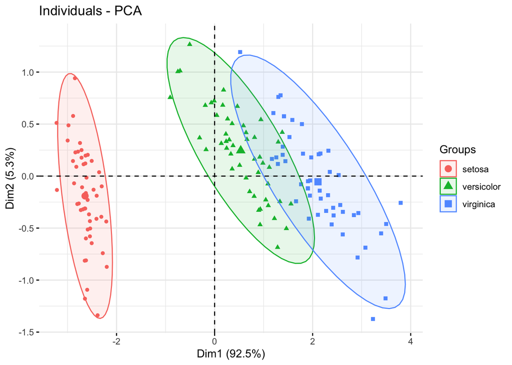

```r
fviz_pca_ind(pr_out, label = "var", habillage=iris_sp,addEllipses=TRUE, ellipse.level=0.95)
```

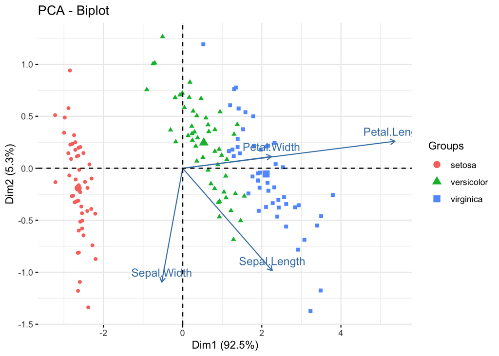

```r
fviz_pca_biplot(pr_out, label = "var", habillage=iris_sp)
```

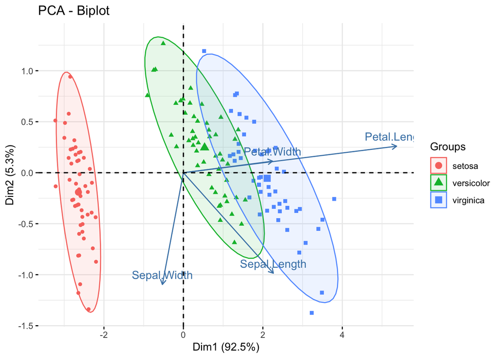

```r
fviz_pca_biplot(pr_out, label = "var", habillage=iris_sp,addEllipses=TRUE, ellipse.level=0.95)
```

## e)

From the standardized PCA, we observe that it requires two principal components to explain more than 90% of the variability in the data (actually then we explain 95%).

When data is standardized, one guideline to pick the number of relevant principal components is to pick the ones with eigen-values (the variances of each components) greater than 1 (which means they explain at least one variable). Check that sum of the eigen-values (variances) is the number of variables (which is four here).

From the plots we can see that after standardizing, the second principal component also contributes to explaining variability. Since the *Petal length*s were already contributing to bigger numbers, a non-standardized version gave much more importance to this attribute. In the standardized version both *Petal length* and *Petal width* tends to get same importance (since they are also quite correlated). Moreover *Sepal width* gets more prominent weights in principal component 1 as well as in principal component 2. The first two components having variances 2.918 and 0.914, it will be natural to choose two principal components here for explaining data variablity (the second PC is not more than one but still quite close).

```r
pr_out_sc<-prcomp(iris_data,scale=T)
summary(pr_out_sc)
```

```
## Importance of components:
##                           PC1    PC2     PC3     PC4
## Standard deviation     1.7084 0.9560 0.38309 0.14393
## Proportion of Variance 0.7296 0.2285 0.03669 0.00518
## Cumulative Proportion  0.7296 0.9581 0.99482 1.00000
```

```r
pr_out_sc$sdev^2
```

```
## [1] 2.91849782 0.91403047 0.14675688 0.02071484
```

```r
sum((pr_out_sc$sdev)^2)
```

```
## [1] 4
```

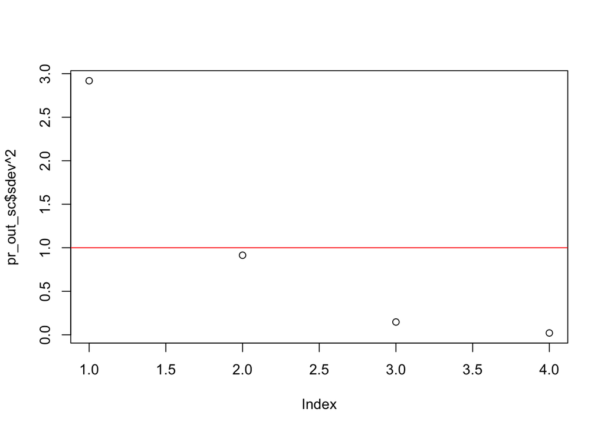

```
## integer(0)
```

```r
plot(pr_out_sc$sdev^2)+abline(h=1,col="red")
```

```r
pve_sc<-pr_out_sc$sdev^2/sum(pr_out_sc$sdev^2)
cpve_sc<-cumsum(pve_sc)
pve_sc
```

```
## [1] 0.729624454 0.228507618 0.036689219 0.005178709
```

```r
cpve_sc
```

```
## [1] 0.7296245 0.9581321 0.9948213 1.0000000
```

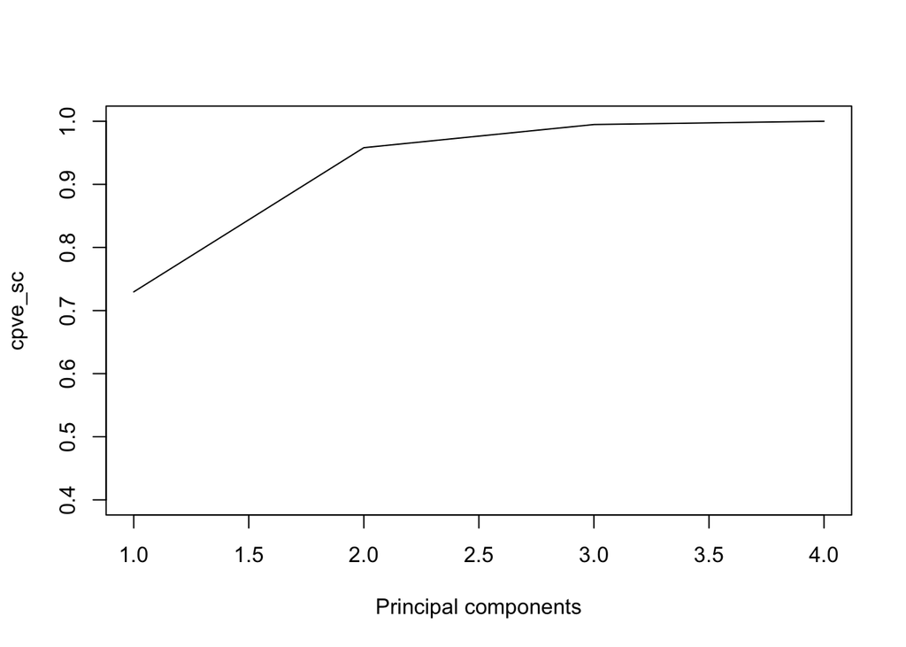

```r
plot(cpve_sc,xlab="Principal components",type="l",ylim=c(0.4,1))
```

```r
# compare with the unscaled case:
#plot(cpve,xlab="Principal components",type="l",ylim=c(0.4,1))
```

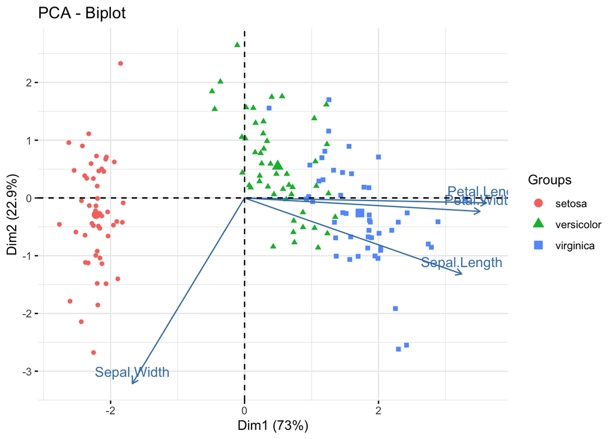

```r
library(factoextra)
fviz_pca_biplot(pr_out_sc, label = "var", habillage=iris_sp)
```

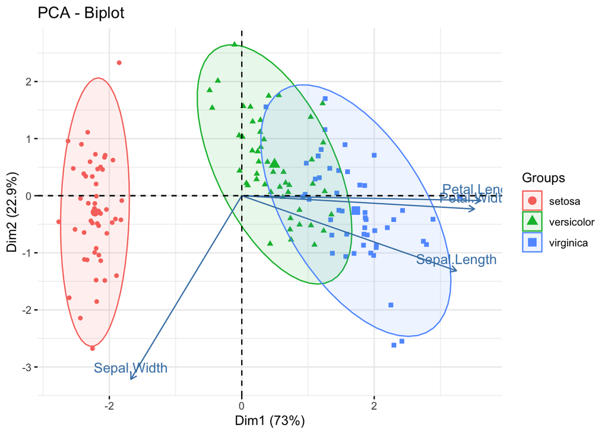

```r
fviz_pca_biplot(pr_out_sc, label = "var", habillage=iris_sp,addEllipses=TRUE, ellipse.level=0.95)
```

# Question 3

## (a)

First we create the variable `exper2` and run linear regression.

```r
mroz <- read.csv("mroz.csv")
mroz$exper2 <- mroz$exper^2
m1 <- lm(hours~., data = mroz)
sum_m <- summary(m1)
sum_m
```

```
##
## Call:
## lm(formula = hours ~ ., data = mroz)
##
## Residuals:
##     Min      1Q  Median      3Q     Max
## -1511.3  -537.8  -146.9   538.1  3555.6
##
## Coefficients:
##              Estimate Std. Error t value Pr(>|t|)
## (Intercept) 1330.4824   270.7846   4.913 1.10e-06 ***
## kidslt6     -442.0899    58.8466  -7.513 1.66e-13 ***
## kidsge6      -32.7792    23.1762  -1.414   0.1577
## age          -30.5116     4.3639  -6.992 6.04e-12 ***
## educ          28.7611    12.9546   2.220   0.0267 *
## exper         65.6725     9.9630   6.592 8.23e-11 ***
## nwifeinc      -3.4466     2.5440  -1.355   0.1759
## exper2        -0.7005     0.3246  -2.158   0.0312 *
## ---
## Signif. codes:  0 '***' 0.001 '**' 0.01 '*' 0.05 '.' 0.1 ' ' 1
##
## Residual standard error: 750.2 on 745 degrees of freedom
## Multiple R-squared:  0.2656, Adjusted R-squared:  0.2587
## F-statistic:  38.5 on 7 and 745 DF,  p-value: < 2.2e-16
```

```r
sum_m$r.squared
```

```
## [1] 0.2656245
```

```r
sum_m$adj.r.squared
```

```
## [1] 0.2587243
```

The R-squared of the model is 0.2656245. The adjusted R-squared of the model is 0.2587243. The fitted equation is
$$\begin{equation*}
\begin{split}
\text{hours} = 1330.48 − && 442.09\text{kidslt6} −
32.78\text{kidsge6} − 30.51 \text{age} + 28.76 \text{educ}\\
+ && 65.67 \text{exper} − 3.45 \text{nwifeinc} − 0.70
\text{exper2}
\end{split}
\end{equation*}$$

## b)

```r
range(m1$fitted)
```

```
## [1] -719.7679 1614.6933
```

```r
summary(m1$fitted)
```

```
##    Min. 1st Qu.  Median    Mean 3rd Qu.    Max.
##  -719.8   417.5   737.7   740.6  1093.1  1614.7
```

```r
table(m1$fitted<0)
```

```
##
## FALSE  TRUE
##   714    39
```

```r
table(mroz$hours==0)
```

```
##
## FALSE  TRUE
##   428   325
```

The range of fitted values from part (a) is $[−719.77, 1614.69]$. The number of fitted values below zero is 39, whereas the data set contains 325 observations that have hours equal to zero. Hence there seems to be a huge disparity.

## c)

We use the library `survival` to fit a Tobit model.

```r
library(survival)
m2 <- survreg(Surv(hours,hours>0,type="left")~.,data=mroz,dist="gaussian")
summary(m2)
```

```
##
## Call:
## survreg(formula = Surv(hours, hours > 0, type = "left") ~ .,
##     data = mroz, dist = "gaussian")
##                 Value Std. Error      z       p
## (Intercept)  965.3053   446.4361   2.16 0.03060
## kidslt6     -894.0217   111.8780  -7.99 1.3e-15
## kidsge6      -16.2180    38.6414  -0.42 0.67470
## age          -54.4050     7.4185  -7.33 2.2e-13
## educ          80.6456    21.5832   3.74 0.00019
## exper        131.5643    17.2794   7.61 2.7e-14
## nwifeinc      -8.8142     4.4591  -1.98 0.04808
## exper2        -1.8642     0.5377  -3.47 0.00053
## Log(scale)     7.0229     0.0371 189.51 < 2e-16
##
## Scale= 1122
##
## Gaussian distribution
## Loglik(model)= -3819.1   Loglik(intercept only)= -3954.9
##  Chisq= 271.59 on 7 degrees of freedom, p= 7e-55
## Number of Newton-Raphson Iterations: 4
## n= 753
```

```r
summary(m1)
```

```
##
## Call:
## lm(formula = hours ~ ., data = mroz)
##
## Residuals:
##     Min      1Q  Median      3Q     Max
## -1511.3  -537.8  -146.9   538.1  3555.6
##
## Coefficients:
##              Estimate Std. Error t value Pr(>|t|)
## (Intercept) 1330.4824   270.7846   4.913 1.10e-06 ***
## kidslt6     -442.0899    58.8466  -7.513 1.66e-13 ***
## kidsge6      -32.7792    23.1762  -1.414   0.1577
## age          -30.5116     4.3639  -6.992 6.04e-12 ***
## educ          28.7611    12.9546   2.220   0.0267 *
## exper         65.6725     9.9630   6.592 8.23e-11 ***
## nwifeinc      -3.4466     2.5440  -1.355   0.1759
## exper2        -0.7005     0.3246  -2.158   0.0312 *
## ---
## Signif. codes:  0 '***' 0.001 '**' 0.01 '*' 0.05 '.' 0.1 ' ' 1
##
## Residual standard error: 750.2 on 745 degrees of freedom
## Multiple R-squared:  0.2656, Adjusted R-squared:  0.2587
## F-statistic:  38.5 on 7 and 745 DF,  p-value: < 2.2e-16
```

## d)

We follow the instructions and compute the values below.

```r
summary(m1)
```

```
##
## Call:
## lm(formula = hours ~ ., data = mroz)
##
## Residuals:
##     Min      1Q  Median      3Q     Max
## -1511.3  -537.8  -146.9   538.1  3555.6
##
## Coefficients:
##              Estimate Std. Error t value Pr(>|t|)
## (Intercept) 1330.4824   270.7846   4.913 1.10e-06 ***
## kidslt6     -442.0899    58.8466  -7.513 1.66e-13 ***
## kidsge6      -32.7792    23.1762  -1.414   0.1577
## age          -30.5116     4.3639  -6.992 6.04e-12 ***
## educ          28.7611    12.9546   2.220   0.0267 *
## exper         65.6725     9.9630   6.592 8.23e-11 ***
## nwifeinc      -3.4466     2.5440  -1.355   0.1759
## exper2        -0.7005     0.3246  -2.158   0.0312 *
## ---
## Signif. codes:  0 '***' 0.001 '**' 0.01 '*' 0.05 '.' 0.1 ' ' 1
##
## Residual standard error: 750.2 on 745 degrees of freedom
## Multiple R-squared:  0.2656, Adjusted R-squared:  0.2587
## F-statistic:  38.5 on 7 and 745 DF,  p-value: < 2.2e-16
```

```r
cor(m1$fitted,mroz$hours)^2
```

```
## [1] 0.2656245
```

```r
p2 <- predict(m2,newdata=mroz)
predict2 <- (p2*pnorm(p2/m2$scale)) + (m2$scale*dnorm(p2/m2$scale))
cor(predict2,mroz$hours)^2
```

```
## [1] 0.2742441
```

The $R^2$-value in the linear model (part (a)) is 0.266. The Tobit model gives an $R^2$-value of 0.274 which is higher than 0.266 and hence the Tobit model is preferred one here.

## e)

We follow the instructions to find the estimated values below.

```r
const1 <- m1$coef[1] + m1$coef[2]*mean(mroz$kidslt6) + m1$coef[3]*mean(mroz$kidsge6) + m1$coef[4]*mean(mroz$age) + m1$coef[6]*mean(mroz$exper) + m1$coef[7]*mean(mroz$nwifeinc) + m1$coef[8]*mean(mroz$exper2)
const1 + m1$coef[5]*8
```

```
## (Intercept)
##    617.2817
```

```r
const1 + m1$coef[5]*12
```

```
## (Intercept)
##    732.3262
```

```r
const2 <- m2$coef[1] + m2$coef[2]*mean(mroz$kidslt6) + m2$coef[3]*mean(mroz$kidsge6) + m2$coef[4]*mean(mroz$age) + m2$coef[6]*mean(mroz$exper) + m2$coef[7]*mean(mroz$nwifeinc) + m2$coef[8]*mean(mroz$exper2)
((m2$coef[5]*8+const2)*pnorm(((m2$coef[5]*8+const2))/m2$scale)) + (m2$scale*dnorm(((m2$coef[5]*8+const2))/m2$scale))
```

```
##     educ
## 423.5725
```

```r
((m2$coef[5]*12+const2)*pnorm(((m2$coef[5]*12+const2))/m2$scale)) + (m2$scale*dnorm(((m2$coef[5]*12+const2))/m2$scale))
```

```
##     educ
## 597.6833
```

The estimate value of hours worked at 8 and 12 years of education from the linear regression model is 617.28 and 732.33 respectively. For the Tobit model, given 8 and 12 years of education, we estimate respectively the values of 423.57 and 597.68. The values from the Tobit model give lower estimates of expected hours worked for these levels of education.

There is an increasing marginal effect of education on the hours worked in the Tobit model as compared to the linear model, as the difference in hours worked at 12 and 8 years of education is higher in the Tobit model.